# Ranking 200 mejores nadadores por prueba

Cueva Tomas

2023-01-12

# Análisis exploratorio del ranking de los 200 nadadores más rapidos por prueba

Bienvenidos a este Rmarkdown en donde analizaremos el dataset que comprende a los 200 nadadores más rapidos por cada prueba, este ranking se desarrola a partir de los mejores tiempos realizados en cada evento profesional realizado en albercas de 50 metros. Con este conjunto de datos vamos a analizar:

## Inicialización de entorno

En principio debemos instalar y llamar a las librerias que utilizaremos.

```r
#install.packages("e1071")
#install.packages("caTools")
#install.packages("class")
#install.packages("ggplot2")
#install.packages("DT")
#install.packages("tidymodels")
#install.packages("rpart.plot")
#install.packages("tidyverse")
#install.packages("dplyr")
```

```r
library(tidyverse)
library(dplyr)
library(e1071)
library(caTools)
library(class)
library(ggplot2)
library(DT)
library(tidymodels)
library(rpart.plot)
library(stringr)
```

## Preparamos nuestras funciones

```r
data_description <- function(data){
  na <- sum(is.na(data))
  if(na == 0){
    description <- "El dataframe no tiene valores na."
  }else{
    decription <- "El dataframe SI TIENE valores na."
    na.omit(data)
    print("se eliminarion "+ na + " valores NA")
  }

  description <-cat(description ,"\n", "Contiene " , nrow(data), " filas y ",ncol(data), " columnas","\n","Con las siguientes variables: ",names(data))

  return(description)
}

mean_age <- function(data,G){
  new_df <- data %>%
    select(Athlete.Full.Name, Age.to.swim, Gender) %>%
    unique() %>%
    filter(Gender == G) %>%
    group_by(Age.to.swim) %>%
    summarise(
      Amount.Swimmers = sum(Age.to.swim/Age.to.swim)
    ) %>%
    arrange(desc(Amount.Swimmers))

  ggplot(
  data =new_df,
  mapping = aes(
    x =Age.to.swim,
    y = Amount.Swimmers)
) +
  geom_bar( stat = "identity")

}

gender_select <- function(data,gender){
  dataframe <- data %>%
    filter(Gender == gender) %>%
    select(Athlete.Full.Name,Team.Name,Gender) %>%
    unique() %>%
    group_by(Team.Name) %>%
    transmute(
      Team.Name = as.factor(Team.Name),
      id.team.code = as.factor(Team.Name),
      id.team.code = as.integer(id.team.code),
    ) %>%
    summarise(
      Amount.Swimmers = sum(id.team.code/id.team.code)
    ) %>%
    arrange(desc(Team.Name))

  dataframe <- dataframe %>%
    mutate(
      Gender = gender
    )

  return(dataframe)
}
```

Finalmente, importaremos nuestro dataset a una variable.

```r
data <- read.csv("../data/best_swimmers.csv", sep = ",")
```

## Descripción del dataset

Describimos el dataset de manera sencilla para tener una vista general del mismo.

```r
print(data_description(data))
```

```
## El dataframe no tiene valores na.
##  Contiene  5200  filas y  14  columnas
##  Con las siguientes variables:  index Event.Name Swim.time Swim.date Event.description Team.Code Team.Name Athlete.Full.Name Gender Athlete.birth.date Rank_Order City Country.Code Duration..hh.mm.ss.ff.NULL
```

```r
glimpse(data)
```

```
## Rows: 5,200
## Columns: 14
## $ index                  <int> 0, 1, 2, 3, 4, 5, 6, 7, 8, 9, 10, 11, 12, 13, 1…
## $ Event.Name             <chr> "European Championships 2022", "13th FINA World…
## $ Swim.time              <chr> "46.86", "46.91", "46.94", "46.96", "46.98", "4…
## $ Swim.date              <chr> "08-13-22", "07-30-09", "04-23-09", "07-25-19",…
## $ Event.description      <chr> "Men 100 Freestyle LCM Male", "Men 100 Freestyl…
## $ Team.Code              <chr> "ROU", "BRA", "FRA", "USA", "ROU", "USA", "AUS"…
## $ Team.Name              <chr> "Romania", "Brazil", "France", "United States o…
## $ Athlete.Full.Name      <chr> "POPOVICI, David", "CIELO FILHO, Cesar", "BERNA…
## $ Gender                 <chr> "M", "M", "M", "M", "M", "M", "M", "M", "M", "M…
## $ Athlete.birth.date     <chr> "09-15-04", "01-10-87", "05-01-83", "08-16-96",…
## $ Rank_Order             <int> 1, 2, 3, 4, 5, 6, 7, 8, 9, 10, 11, 12, 13, 14, …
## $ City                   <chr> "Rome", "Rome", "Montpellier", "Gwangju", "Rome…
## $ Country.Code           <chr> "ITA", "ITA", "FRA", "KOR", "ITA", "JPN", "AUS"…
## $ Duration..hh.mm.ss.ff. <chr> "0:0:46:86", "0:0:46:91", "0:0:46:94", "0:0:46:…
```

## Transformación general

Ahora haremos la primer transformación, la cual comprende:

- Reescribir la variable data con el dataframe transformado
- Eliminar las columnas:
  - Swim.time: Ya que el tiempo de nado lo tendremos diferenciado en otras columnas.
  - Team.Code: Ya que nos da información ya repetida, proveniente de Team.name, la cual nos da un poco más de información.
  - index: Innecesaria ya que tenemos el ranking y el indice autogenerado.
  - Duration..hh.mm.ss.ff. : La eliminaremos ya que generaremos 4 columnas más que posean un tipo de dato apropiado para lo que necesitaremos posteriormente.
  - Aprovecharemos a dejar el dato de la “hora” en el tiempo de nado ya que en carreras en piscinas de 50 metros no existen carreras que requieran estar más de 30 minutos nadando.
- Para verificar que las fechas sean correctas, filtraremos todas aquellas que sobrepasen el 01-01-2023.

```r
data <- data %>%
  mutate(
    Swim.time = NULL,
    Event.Name = as.factor(Event.Name),
    Event.description = as.factor(Event.description),
    City = as.factor(City),
    Country.Code = as.factor(Country.Code),
    Swim.date = as.Date(Swim.date, "%m-%d-%y"),
    Athlete.birth.date = as.Date(Athlete.birth.date,"%m-%d-%y"),
    Team.Name = as.factor(Team.Name),
    Team.Code = NULL,
    Duration..hh.mm.ss.ff. = str_split(Duration..hh.mm.ss.ff. , ":", simplify = TRUE),
    Minute =as.integer(Duration..hh.mm.ss.ff.[,2]),
    Second = as.integer(Duration..hh.mm.ss.ff.[,3]),
    hundredths = as.integer(Duration..hh.mm.ss.ff.[,4]),
    Duration..hh.mm.ss.ff. = NULL,
    index = NULL,
    Gender = as.factor(Gender),
    Age.to.swim = as.integer(trunc(as.numeric((`Swim.date`- `Athlete.birth.date`)/365)))
  ) %>%
  filter(
    Swim.date < as.Date("2023-01-01") & Athlete.birth.date < as.Date("2023-01-01")
  ) %>%
  arrange(desc(Event.description))

glimpse(data)
```

```
## Rows: 5,197
## Columns: 14
## $ Event.Name         <fct> Olympic Games Rio 2016, ST Arena Pro Swim at Austin…
## $ Swim.date          <date> 2016-08-12, 2016-01-17, 2018-05-19, 2015-08-08, 20…
## $ Event.description  <fct> Women 800 Freestyle LCM Female, Women 800 Freestyle…
## $ Team.Name          <fct> "United States of America", "United States of Ameri…
## $ Athlete.Full.Name  <chr> "LEDECKY, Katie", "LEDECKY, Katie", "LEDECKY, Katie…
## $ Gender             <fct> F, F, F, F, F, F, F, F, F, F, F, F, F, F, F, F, F, …
## $ Athlete.birth.date <date> 1997-03-17, 1997-03-17, 1997-03-17, 1997-03-17, 19…
## $ Rank_Order         <int> 1, 2, 3, 4, 5, 6, 7, 8, 9, 10, 11, 12, 13, 14, 15, …
## $ City               <fct> "Rio de Janeiro", "Austin", "Indianapolis", "Kazan"…
## $ Country.Code       <fct> BRA, USA, USA, RUS, HUN, JPN, USA, USA, USA, USA, U…
## $ Minute             <int> 8, 8, 8, 8, 8, 8, 8, 8, 8, 8, 8, 8, 8, 8, 8, 8, 8, …
## $ Second             <int> 4, 6, 7, 7, 8, 9, 9, 10, 10, 10, 11, 11, 11, 11, 11…
## $ hundredths         <int> 79, 68, 27, 39, 4, 13, 27, 32, 70, 91, 0, 8, 21, 35…
## $ Age.to.swim        <int> 19, 18, 21, 18, 25, 21, 25, 19, 22, 19, 17, 21, 17,…
```

## Cantidad de nadadores por equipo

Crearemos una tabla para visualizar la cantidad de nadadores por equipo. De esta forma podremos ver que país es aquel que posee el mejor nivel profesional.

```r
data %>%
  select(Athlete.Full.Name,Team.Name) %>%
  unique() %>%
  group_by(Team.Name) %>%
  transmute(
    Team.Name = as.factor(Team.Name),
    id.Team.Name = as.factor(Team.Name),
    id.Team.Name = as.integer(id.Team.Name)
  ) %>%
  summarise(
    Amount.Swimmers = sum(id.Team.Name/id.Team.Name)
  ) %>%
  arrange(desc(Amount.Swimmers)) %>%
  slice(1:10) %>%
  DT::datatable(
    rownames = F,
    filter = "top"
  )
```

| Team.Name | Amount.Swimmers |
| --- | --- |
| United States of America | 145 |
| Australia | 83 |
| People's Republic of China | 64 |
| Japan | 54 |
| Great Britain | 40 |
| Russian Federation | 34 |
| France | 30 |
| Italy | 30 |
| Canada | 28 |
| Germany | 27 |

## Edad promedio de rendimiento

Como es de amplio conocimiento,el organismo, por razones biologicas, tiene una etapa en donde consigue su mejor nivel fisico, en la natación profesional esto es muy notorio, ya que es un deporte de alto rendimiento y de alguna u otra forma, a medida que el atleta crece ya en una etapa adulta, su rendimiento empieza a decaer, como también es dificil comparar el nivel fisico de un adolescente con un adulto.

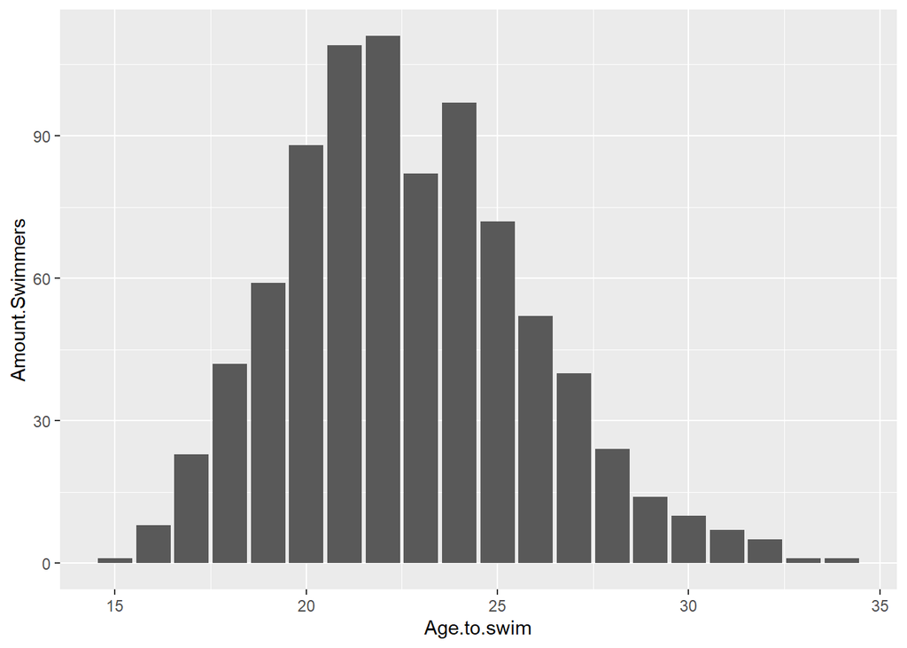

```r
mean_age(data,"M")
```

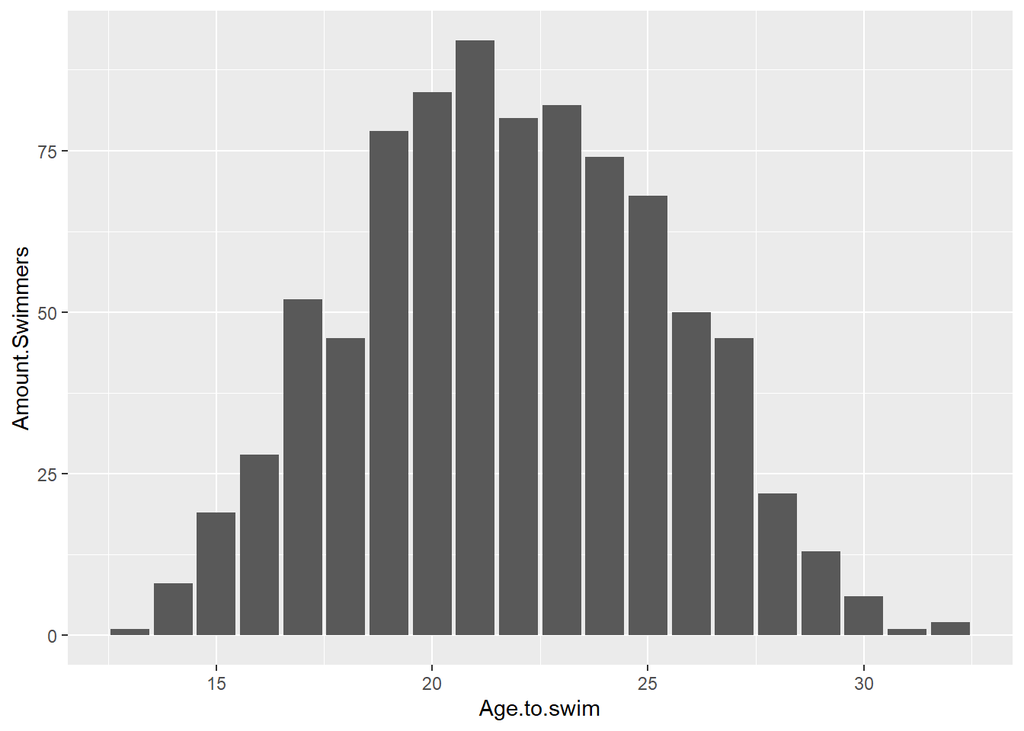

```r
mean_age(data,"F")
```

Como podemos observar, la mejor etapa de rendimiento a nivel profesional en hombres, se encuentra entre los 20 a 25 años de edad. En la categoría femenina, la franja etaria se extiende solo un poco más, observando una cantidad considerable de nadadoras dentro del top 200 de cada prueba a la edad de 17 hasta los 26 años.

## Diferencia entre hombres y mujeres

En el siguiente grafico se muestra cantidad de hombres y mujeres en cada país perteneciente a este ranking 200.

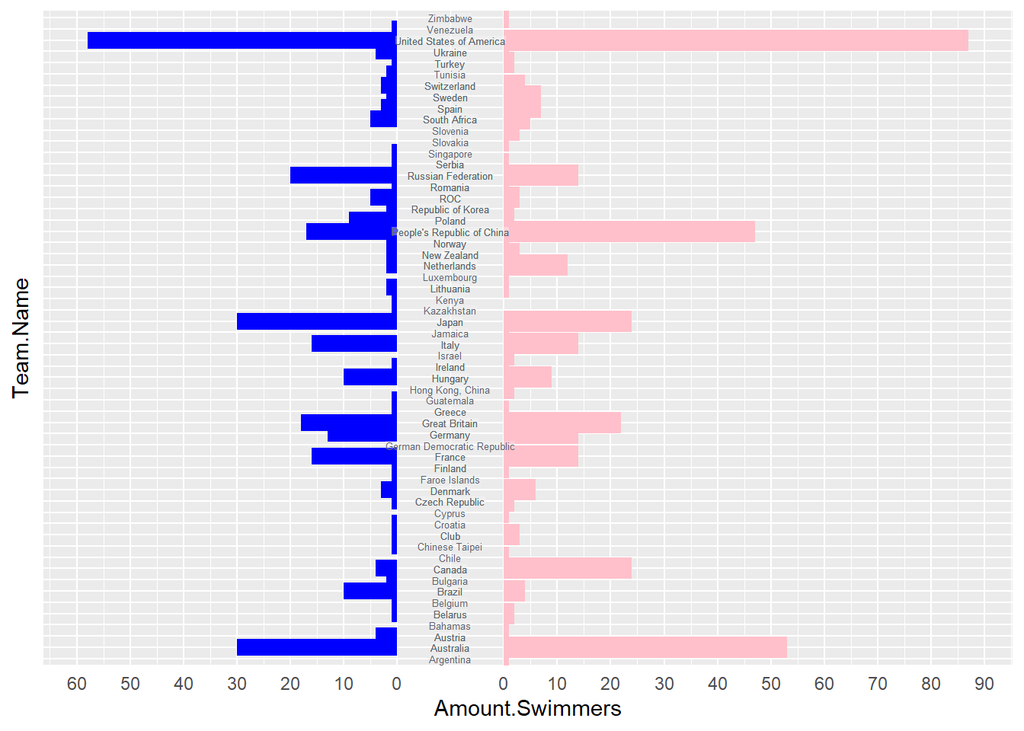

```r
female_df <- gender_select(data,"F")
male_df <- gender_select(data,"M")

df_swimmers <- full_join(male_df,female_df)

displacement <- 10
ggplot(df_swimmers, aes(x = `Team.Name`,
                        y = `Amount.Swimmers`),
       width = 800)+
  geom_linerange(data = subset(df_swimmers, Gender == "M") %>%
                   mutate(`Amount.Swimmers` = -`Amount.Swimmers`),
                 aes(ymin = -displacement,
                     ymax = -displacement + `Amount.Swimmers`),
                 size = 4,
                 color = "blue")+
  geom_linerange(data = subset(df_swimmers, Gender == "F"),
                 aes(ymin = displacement,
                     ymax = displacement + `Amount.Swimmers`),
                 size = 5,
                 color = "pink")+
  coord_flip()+
  scale_y_continuous(
    breaks = c(seq(-90 ,0,by=10)-displacement,
               seq(0,90,by = 10)+displacement),
    labels = c(rev(seq(0,90, by = 10)), seq(0,90, by = 10))
  )+
  theme(plot.title = element_text(hjust = .5),
        axis.ticks = element_blank(),
        axis.text.y = element_blank(),
        )+
  geom_label(aes(x = `Team.Name`,
                 y = 0,
                 label = `Team.Name`),
             label.padding = unit(0.0,"lines"),
             label.size = 0,
             size = 1.75,
             label.r = unit(0.0,"lines"),
             fill = "#FAFAFA",
             alpha = 0.2,
             color = "#5D646F")
```

```r
data %>%
  select(Event.Name) %>%
  group_by(Event.Name) %>%
  transmute(
    Event.Name = Event.Name,
    id.Event.Name = as.integer(Event.Name),
  ) %>%
  summarise(
    Count = sum(id.Event.Name/id.Event.Name)
  ) %>%
  arrange(desc(Event.Name)) %>%
  slice(1:10) %>%
  DT::datatable(
    rownames = F,
    filter = "top"
  )
```

| Event.Name | Count |
| --- | --- |
| Youth Olympic Games Nanjing 2014 | 3 |
| Youth Olympic Games Buenos Aires 2018 | 1 |
| Victorian Open Championships 2022 | 2 |
| Victorian Open Championships 2016 | 3 |
| USA Winter National Championships (50m) | 19 |
| USA Olympic Trials 2004 | 4 |
| USA Olympic Team Trials | 5 |
| US Winter National Championships (50m) | 5 |
| US Spring National Championships (50m) | 2 |
| US Santa Clara International 2012 | 1 |